# Sample_Report_2

Compiled: May 15, 2019

## R Markdown

This R Markdown aims to provide a brief summary of all diagnostic plots for your RNA-seq experiment. The fastq files are available for upon request.

Users receiving files from RSCshare are advised to delete all files once they have secure copied them to their own respective drives.

a copy of your data will be securely archived on our end

## Multiqc HTML

The multiqc html summarises the alignment statistics along with the summary of raw counts generated via [STAR](https://academic.oup.com/bioinformatics/article/29/1/15/272537);

The raw fastq reads were first processed with **trim-galore** (Barbraham Institute) package to:

- Filter for low quality reads;
- 2 color chemistry bias (next-seq);
- Filter for noisy short fragments;
- Filter for adapter sequence;

```bash
trim_galore --nextseq 20 --gzip --length 50 --paired --fastqc
```

* --paired only applicable for paired-end data; --length 10 for smRNA-seq libraries

## geneBodyCoverage

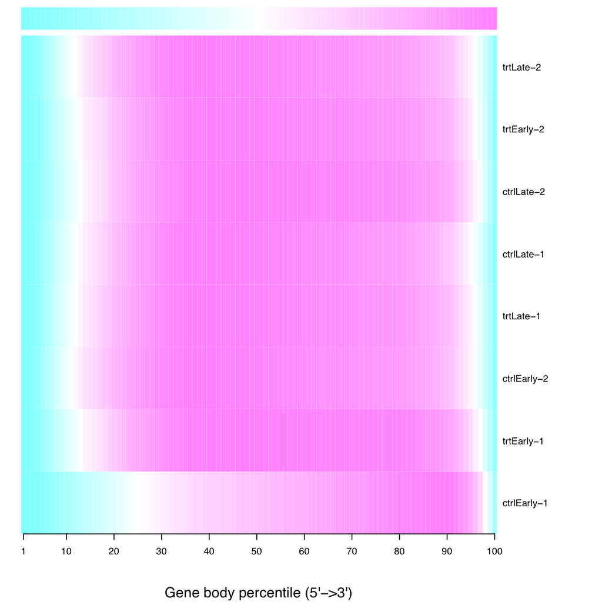

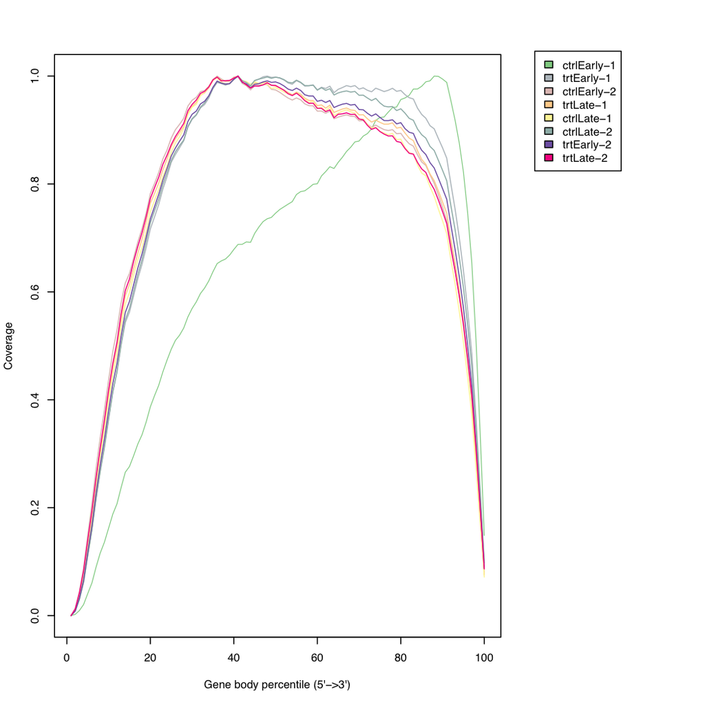

A good library should indicate little to no bias across the entire gene body.

## countsDistribution

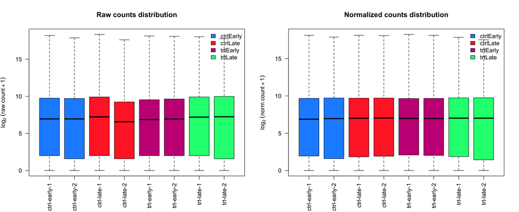

Post-normalization, the medians should be consistent across samples and more similar between biological replicates.

## sampleCluster

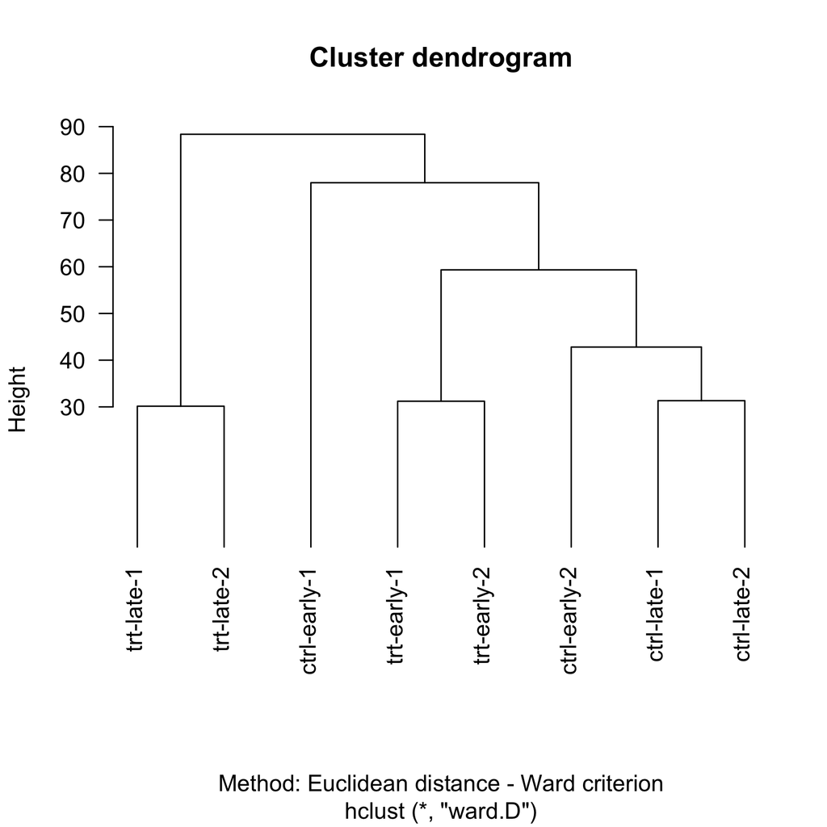

An euclidean distance is computed between samples, and the dendrogram is built upon the Ward criterion. We expect this dendrogram to group replicates and separate biological conditions.

## principalComponents

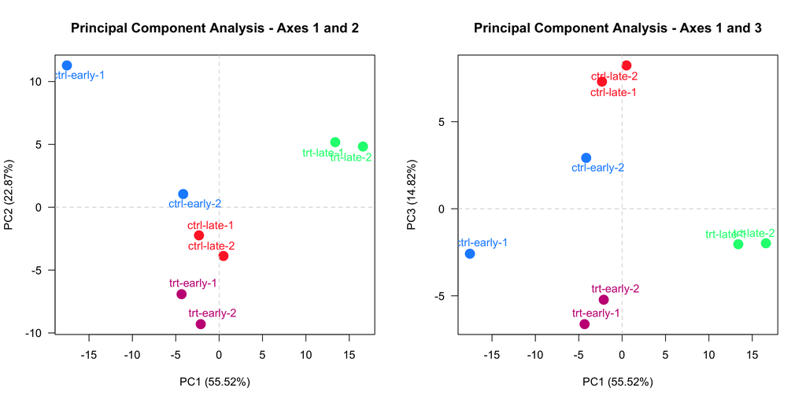

Another way of visualizing the experiment variability is to look at the first principal components of the PCA. On this figure, the first principal component (PC1) is expected to separate samples from the different biological conditions, meaning that the biological variability is the main source of variance in the data.

## citations

```r
citation("DESeq2")
```

```
##
##   Love, M.I., Huber, W., Anders, S. Moderated estimation of fold
##   change and dispersion for RNA-seq data with DESeq2 Genome
##   Biology 15(12):550 (2014)
##
## A BibTeX entry for LaTeX users is
##
##   @Article{,
##     title = {Moderated estimation of fold change and dispersion for RNA-seq data with DESeq2},
##     author = {Michael I. Love and Wolfgang Huber and Simon Anders},
##     year = {2014},
##     journal = {Genome Biology},
##     doi = {10.1186/s13059-014-0550-8},
##     volume = {15},
##     issue = {12},
##     pages = {550},
##   }
```

```r
citation("SARTools")
```

```
##
##   Hugo Varet, Loraine Brillet-GuÃ©guen, Jean-Yves CoppÃ©e and
##   Marie-AgnÃ¨s Dillies (2016): SARTools: A DESeq2- and EdgeR-Based
##   R Pipeline for Comprehensive Differential Analysis of RNA-Seq
##   Data. PLoS One, 2016, doi:
##   http://dx.doi.org/10.1371/journal.pone.0157022
##
## A BibTeX entry for LaTeX users is
##
##   @Article{,
##     title = {SARTools: A DESeq2- and EdgeR-Based R Pipeline for Comprehensive Differential Analysis of RNA-Seq Data},
##     author = {Hugo Varet and Loraine Brillet-GuÃ©guen and Jean-Yves CoppÃ©e and Marie-AgnÃ¨s Dillies},
##     year = {2016},
##     journal = {PLoS One},
##     doi = {10.1371/journal.pone.0157022},
##     url = {http://dx.doi.org/10.1371/journal.pone.0157022},
##   }
```